# 06_meta_mapping

Gulnara Tagridzhanova

10/08/2023

- **Rationale:** Now the main focus of this sub-project is the metatranscriptomic data produced for Xanthoria

## 1. Sample overview

- 19 samples from 5 substrates and 4 sample types

```r
library(tidyverse)
samples<-read.delim("../data/metadata/found_samples_in_sequences_db_thallus.csv",sep=",")

samples %>% group_by(growth_site,sample_focus) %>% summarize(n=n()) %>%
  pivot_wider(names_from = growth_site,values_from = n,values_fill = 0)
```

```
## # A tibble: 4 × 6
##   sample_focus    bark filter metal_bridge stone_fence twigs
##   <chr>          <int>  <int>        <int>       <int> <int>
## 1 apothecia          2      0            0           3     2
## 2 thallus_centre     2      0            1           2     1
## 3 thallus_edge       2      0            0           1     1
## 4 whole_thallus      0      2            0           0     0
```

- Have 4 complete sets: 2 from bark, 1 from twigs, 1 from stone
  - One complete set = 3 metatranscriptomes: thallus_centre, thallus_edge, apothecia

```r
samples %>% filter(sample_focus %in% c("apothecia","thallus_centre","thallus_edge")) %>%
  group_by(sample_focus,thallus_id) %>% summarize(n=n()) %>% pivot_wider(names_from = sample_focus, values_from = n, values_fill = 0)
```

```
## # A tibble: 7 × 4
##   thallus_id apothecia thallus_centre thallus_edge
##   <chr>          <int>          <int>        <int>
## 1 XB1                1              1            1
## 2 XB2                1              1            1
## 3 XS1                1              1            0
## 4 XS2                2              1            1
## 5 XT1                1              0            0
## 6 XT2                1              1            1
## 7 XM2                0              1            0
```

## 2. Creating combined transcript file

- Included following for the mycobiont:
  - mrna-transcripts from the funannotate annotation of GTX0501 nuclear MAG
  - transcripts from the MitoFInder annotation of GTX0501 mitogenome
- For other eukaryotes, included annotations of MAGs from from short-read metagenomic assemblies. Used funannotate-generated *.mrna-transcripts.fa
  - this didn’t include short-read MAGs from Xanthoria mycobiont
- For prokaryotes, used prokka-gnerated *.ffn file (Nucleotide FASTA file of all the prediction transcripts (CDS, rRNA, tRNA, tmRNA, misc_RNA))

```
cat ../02_long_read_assemblies/analysis_and_temp_files/06_annotate_lecanoro/GTX0501_pred/annotate_results/Xanthoria_parietina_GTX0501.mrna-transcripts.fa ../02_long_read_assemblies/analysis_and_temp_files/06_annotate_lecanoro/GTX0501mito/GTX0501mito_MitoFinder_mitfi_Final_Results/GTX0501mito_mtDNA_contig_genes_NT.fasta  ../01_Xanthoria_metagenomics/analysis_and_temp_files/06_annotate_mags/prok/*/*.ffn ../01_Xanthoria_metagenomics/analysis_and_temp_files/06_annotate_mags/euk/coassembly.bin.195_pred/predict_results/*.mrna-transcripts.fa ../01_Xanthoria_metagenomics/analysis_and_temp_files/06_annotate_mags/euk/coassembly.bin.376_pred/predict_results/*.mrna-transcripts.fa ../01_Xanthoria_metagenomics/analysis_and_temp_files/06_annotate_mags/euk/coassembly.bin.378_pred/predict_results/*.mrna-transcripts.fa ../01_Xanthoria_metagenomics/analysis_and_temp_files/06_annotate_mags/euk/coassembly.bin.64_pred/predict_results/*.mrna-transcripts.fa ../01_Xanthoria_metagenomics/analysis_and_temp_files/06_annotate_mags/euk/coassembly.bin.76_pred/predict_results/*.mrna-transcripts.fa ../01_Xanthoria_metagenomics/analysis_and_temp_files/06_annotate_mags/euk/GTX0465.bin.1_pred/predict_results/*.mrna-transcripts.fa ../01_Xanthoria_metagenomics/analysis_and_temp_files/06_annotate_mags/euk/GTX0466.bin.15_pred/predict_results/*.mrna-transcripts.fa ../01_Xanthoria_metagenomics/analysis_and_temp_files/06_annotate_mags/euk/GTX0468.bin.53_pred/predict_results/*.mrna-transcripts.fa ../01_Xanthoria_metagenomics/analysis_and_temp_files/06_annotate_mags/euk/GTX0493.bin.23_pred/predict_results/*.mrna-transcripts.fa ../01_Xanthoria_metagenomics/analysis_and_temp_files/06_annotate_mags/euk/GTX0486_487.bin.100_pred/predict_results/*.mrna-transcripts.fa > analysis_and_temp_files/06_meta_mapping/transcripts_all.fa
```

- This resulted in 701,881 transcripts
- Indexed the list with kallisto

```
#!/bin/bash
#SBATCH --time=6:00:00
#SBATCH --cpus-per-task=20
#SBATCH --job-name=annot
#SBATCH --output=analysis_and_temp_files/06_meta_mapping/kallisto_index.log
#SBATCH --mem=80G

source kallisto-0.46.2
kallisto index -i analysis_and_temp_files/06_meta_mapping/transcripts_all.idx analysis_and_temp_files/06_meta_mapping/transcripts_all.fa
```

## 3. Mapping

- Prepped the Snakemake file to map all transcriptomes of interest. Saved it in `analysis_and_temp_files/06_meta_mapping/Snakemake_kallisto`
- Before running it, needed to trim and filter Xanthoria pure culture transcriptomes (updated Snakefile and rarefaction reports in `03_qc`)
- Made a single table with all mapping results, saved in `analysis_and_temp_files/06_meta_mapping/kallisto_report.txt`

## 4. Overview

- Add the column with the MAG, and add info about the taxonomy for each mag

```r
kallisto<-read.delim("../analysis_and_temp_files/06_meta_mapping/kallisto_report.txt",header=F)
colnames(kallisto)<-c("target_id","length","eff_length","est_counts","tpm","sample")

#use the shortened version of the genome name from the locus tag to get the full version
kallisto$locustag_base<-sub("\\_.*", "", kallisto$target_id)
kallisto$genome<-str_replace(kallisto$locustag_base,"b",".bin.")
kallisto$genome<-str_replace(kallisto$genome,"coassem","coassembly")
kallisto$genome<-str_replace(kallisto$genome,"GTX0486","GTX0486_487")

#combine nuclear and mito genomes of the mycobiont
kallisto$genome[grepl("mito",kallisto$genome)]<-"XANPAGTX0501"

#add taxonomi info from the mag table
mag_info<-read.delim("../../01_Xanthoria_metagenomics/analysis_and_temp_files/04_phylogenomics/mags_stats.txt",header=T)
mag_info$genome<-str_replace(mag_info$genome,".fa","")

mag_info$type<-"Bacteria"
mag_info$type[mag_info$classification=="Trebouxia"]<-"Trebouxia"
mag_info$type[mag_info$phylum=="Ascomycota"]<-"other_fungi"

#add a new line for the mycobiont genome
mag_info <- mag_info %>% select(genome,type,classification,phylum,class,order,family,genus,species,domain)

xanpa_info<-c("genome"="XANPAGTX0501","type"="Main fungus", "classification"="Lecanoromycetes",
             "phylum"= "Ascomycota", "class"="Lecanoromycetes","order"="Teloschistales",
             "family"="Teloschistaceae","genus"="Xanthoria","species"="Xanthoria parietina",
             "domain"="Eukaryota")
mag_info <- rbind(mag_info,xanpa_info)

kallisto<-kallisto %>% left_join(mag_info)
#write.table(kallisto,"../analysis_and_temp_files/06_meta_mapping/kallisto_report_add_info.txt",row.names = F,quote = F)
```

- In all samples, mycobiont is dominant

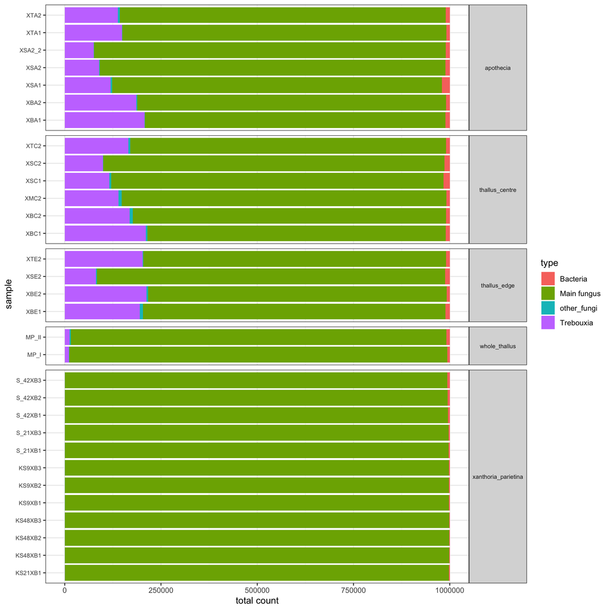

```r
#kallisto<-read.delim("../analysis_and_temp_files/06_meta_mapping/kallisto_report_add_info.txt",header=T)
metadata<-read.csv("../data/metadata/bmm_coculture_thallus.csv")

kallisto_by_type <- kallisto %>% group_by(sample,type) %>% summarize(total_count=sum(tpm)) %>% mutate(freq = round(total_count / sum(total_count), 3)) %>% left_join(metadata,by=c("sample"="run_id"))

ggplot(kallisto_by_type) + geom_bar(aes(x=total_count,y=sample,fill=type),position="stack", stat="identity") + facet_grid(pair~.,scales="free",space="free")+
  xlab("total count") + theme_bw()+
  theme(strip.text.y = element_text(angle = 0,size=7),
        axis.text.y = element_text(size=7))
```

* Same graph, but with MP_I and MP_II samples removed

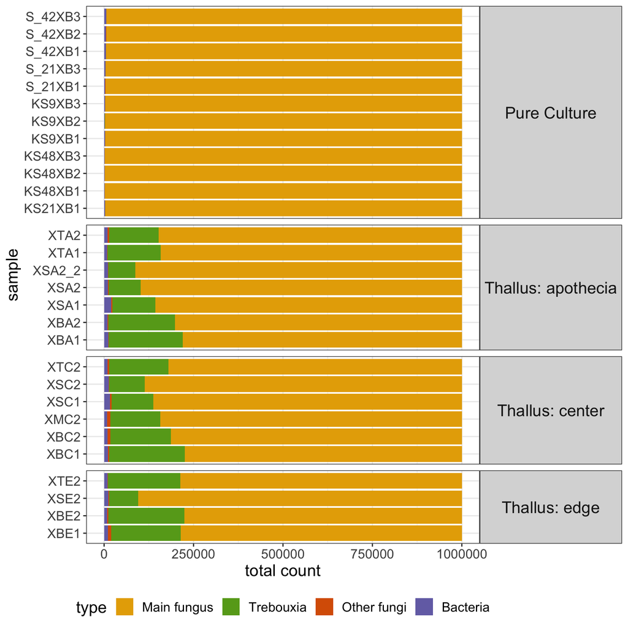

```r
library(RColorBrewer)
kallisto_by_type <- kallisto_by_type %>% mutate(pair2=case_when(pair=="xanthoria_parietina" ~ "Pure Culture",
        pair=="apothecia" ~ "Thallus: apothecia",
        pair=="thallus_centre" ~ "Thallus: center",
       pair=="thallus_edge"  ~ "Thallus: edge",
       pair=="whole_thallus"   ~ "Whole thallus, growth chamber",
       T ~ ""))
kallisto_by_type$type[kallisto_by_type$type=="other_fungi"]<-"Other fungi"
kallisto_by_type$type<-factor(kallisto_by_type$type,levels=c("Main fungus","Trebouxia","Other fungi","Bacteria"))

ggplot(kallisto_by_type %>% filter(pair2 != "Whole thallus, growth chamber")) + geom_bar(aes(x=total_count,y=sample,fill=type),position="stack", stat="identity") + facet_grid(pair2~.,scales="free",space="free")+
  xlab("total count") + theme_bw()+
  scale_fill_manual(values = c("Main fungus"=brewer.pal(8,"Dark2")[6],
                               "Trebouxia"=brewer.pal(8,"Dark2")[5],
                               "Other fungi"=brewer.pal(8,"Dark2")[2],
                               "Bacteria"=brewer.pal(8,"Dark2")[3]))+
  theme(strip.text.y = element_text(angle = 0,size=15),
        #axis.text.y = element_text(size=10),
        text= element_text(size=15),
        legend.position="bottom")
```

```r
kallisto_by_type$type_sample <- "thallus_from_nature"
kallisto_by_type$type_sample[kallisto_by_type$pair=="whole_thallus"] <- "thallus_from_lab"
kallisto_by_type$type_sample[kallisto_by_type$pair=="xanthoria_parietina"] <- "pure_culture"

kallisto_by_type %>% group_by(type,type_sample) %>% summarize(avg_percent=mean(freq)) %>% pivot_wider(names_from = type,values_from = avg_percent)
```

```
## # A tibble: 3 × 5
##   type_sample         `Main fungus` Trebouxia `Other fungi` Bacteria
##   <chr>                       <dbl>     <dbl>         <dbl>    <dbl>
## 1 pure_culture                0.997     0           0        0.00283
## 2 thallus_from_lab            0.979     0.012       0.002    0.008
## 3 thallus_from_nature         0.835     0.150       0.00359  0.0111
```

## 5. Trebouxia by genome

- In three out of four complete sets of samples, on Trebouxia genome (GTX0468.bin.53) is clearly dominant
- In XT1 (incomplete set), the dominant genome is different
- Three others (including one complete set) don’t have a dominant. Probably their strain of alga wasn’t among the genomes, so the reads mapped to whatever algal transcripts fit better this particular gene

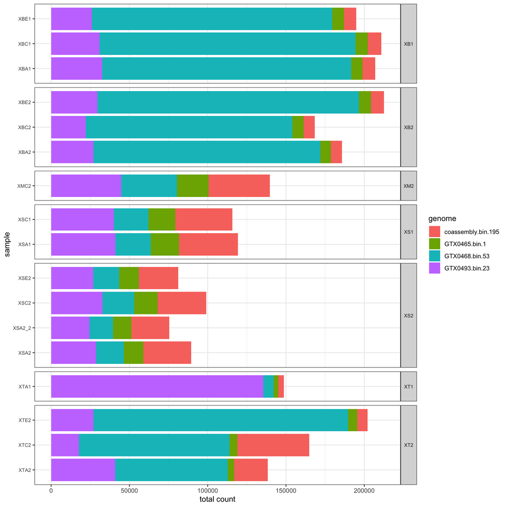

```r
kallisto_treb <- kallisto %>% filter(type=="Trebouxia") %>% group_by(genome,sample) %>% summarize(total_count=sum(tpm)) %>% mutate(freq = round(total_count / sum(total_count), 3)) %>% left_join(metadata,by=c("sample"="run_id")) %>% left_join(samples,by=c("sample"="samples"))

#add info on thalli

ggplot(kallisto_treb %>% filter(pair %in% c("apothecia","thallus_centre","thallus_edge"))) + geom_bar(aes(x=total_count,y=sample,fill=genome),position="stack", stat="identity") + facet_grid(thallus_id~.,scales="free",space="free")+
  xlab("total count") + theme_bw()+
  theme(strip.text.y = element_text(angle = 0,size=7),
        axis.text.y = element_text(size=7))
```

## 6. Dominant bacteria

```r
bac_taxonomy <- mag_info %>% filter(domain =="Bacteria") %>% select(classification,phylum,class,order,family,genus) %>% distinct()

kallisto_bac_by_genus <- kallisto %>% filter(type=="Bacteria") %>% group_by(genus) %>% summarize(total_count=sum(tpm))  %>% arrange(desc(total_count)) %>% filter(genus!="Unknown") %>% left_join(bac_taxonomy)

kallisto_bac_by_genus_2 <- kallisto %>% filter(type=="Bacteria") %>% group_by(genus,sample) %>% summarize(total_count=sum(tpm)) %>% filter(genus!="Unknown") %>% left_join(bac_taxonomy) %>%  left_join(metadata,by=c("sample"="run_id"))
```

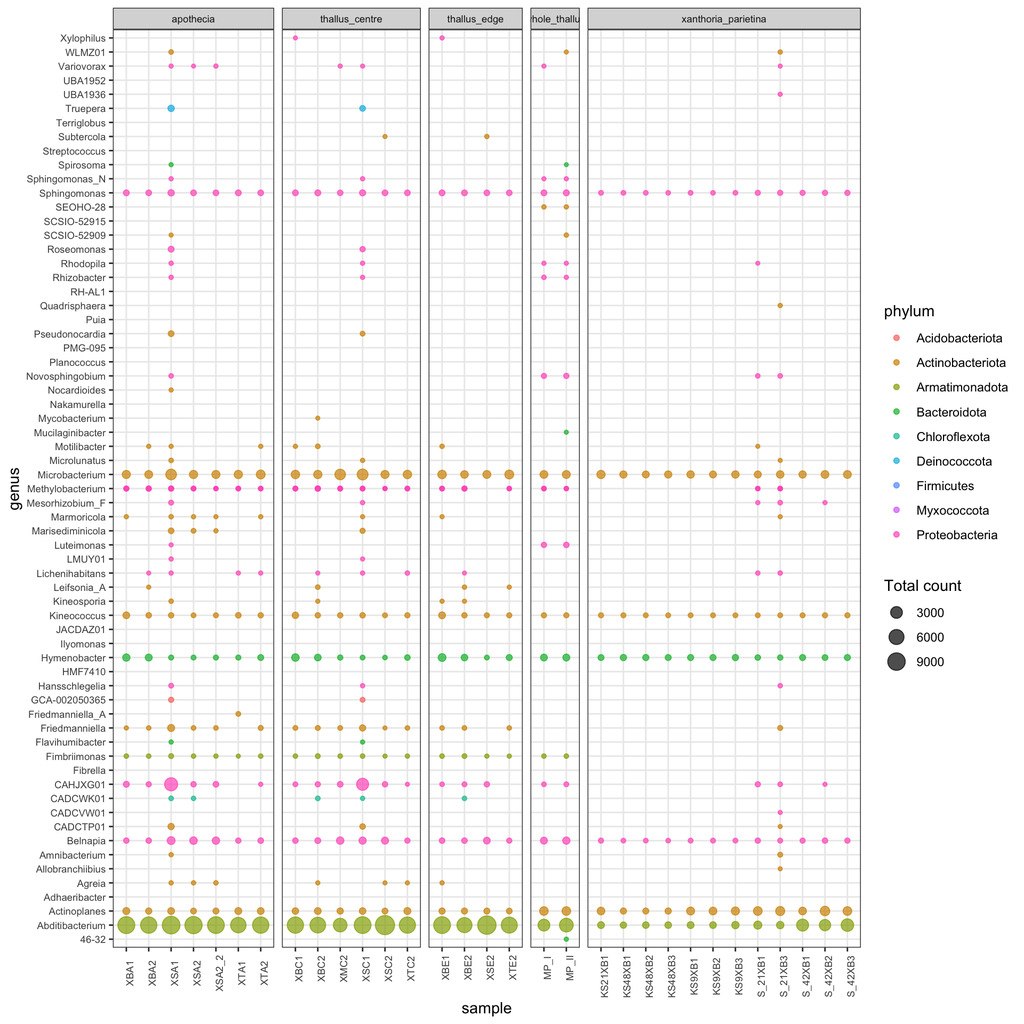

```r
#add info on thalli

ggplot(kallisto_bac_by_genus_2,aes(x=sample,y=genus,size=ifelse(total_count<10, NA, total_count),color=phylum))+geom_point(alpha=0.7)+
  scale_size(range = c(1, 6),name = "Total count")+
  facet_grid(.~pair,scales="free",space="free") + theme_bw()+
  theme(axis.text.x = element_text(angle = 90,size=7),
        axis.text.y = element_text(size=7),
        strip.text = element_text(size=7))
```

### Side-quest: can I really find Sphingomonas in the pure culture data?

- Checked the rRNA files for the presence of Sphingomonas 16S
- Started with one:

```
cp  analysis_and_temp_files/03_qc/trimmed_reads/KS48XB1_trimmed.bbmapmerged.rRNA.fastq.gz analysis_and_temp_files/06_meta_mapping/
gzip -d analysis_and_temp_files/06_meta_mapping/KS48XB1_trimmed.bbmapmerged.rRNA.fastq.gz
cat analysis_and_temp_files/06_meta_mapping/KS48XB1_trimmed.bbmapmerged.rRNA.fastq | awk '{if(NR%4==1) {printf(">%s\n",substr($0,2));} else if(NR%4==2) print;}' > analysis_and_temp_files/06_meta_mapping/KS48XB1_trimmed.bbmapmerged.rRNA.fa
blastn -query analysis_and_temp_files/06_meta_mapping/Sphingomonas_genbank_16s.fa -subject analysis_and_temp_files/06_meta_mapping/KS48XB1_trimmed.bbmapmerged.rRNA.fa -outfmt 6 -out analysis_and_temp_files/06_meta_mapping/blastn_sphingomonas_KS48XB1.txt
```

- Resulted in 334 hits, top 6:

```
AB217471.1      A00783:750:HWNWGDSXY:1:2369:31159:8328  100.000 150     0       0       598     747     150     1       1.37e-73        278
AB217471.1      A00783:750:HWNWGDSXY:1:2369:31159:8328  98.000  150     3       0       513     662     1       150     1.38e-68        261
AB217471.1      A00783:750:HWNWGDSXY:1:1226:24460:29199 97.333  150     4       0       252     401     1       150     6.43e-67        255
AB217471.1      A00917:652:HWV2JDSXY:1:2644:17282:13479 97.333  150     4       0       208     357     150     1       6.43e-67        255
AB217471.1      A00917:652:HWV2JDSXY:1:1231:31901:35978 97.315  149     4       0       253     401     1       149     2.31e-66        254
AB217471.1      A00917:652:HWV2JDSXY:1:1231:32045:35571 97.315  149     4       0       253     401     1       149     2.31e-66        254
```

- Picked three hits and blasted against NCBI
  - Top hit blasts as Sphingomonas
  - Random middle hit (evalue 3.12e-35) blasts as Rhodococcus (Actinomycetes)
  - Bottom hit (evalue 6.90e-17) blasts as unclutured bacterium or chloroplast 16S
- **Conclusion:** it seems that the most likely explantation is bacterial contamination of the cultures, NOT mismapping of reads

## 7. Saved mycobiont info separately

- Shared with Neha

```r
myco <- kallisto %>% filter(type=="Main Fungus") %>%
select(target_id,length,eff_length,est_counts,tpm,sample)


write.table(myco,"../analysis_and_temp_files/06_meta_mapping/kallisto_mycobiont_only.txt",row.names = F,quote = F)
```